# Gráficos en R

## Graficos básicos (qplot)

## Carga de librerias

```r
# Borrado del entorno de trabajo
rm(list=ls())

gc()
```

```
##           used (Mb) gc trigger (Mb) limit (Mb) max used (Mb)
## Ncells  602035 32.2    1362281 72.8         NA   715637 38.3
## Vcells 1131113  8.7    8388608 64.0      65536  2010446 15.4
```

```r
require("data.table")
require("ggplot2")
```

## Función qplot

```r
help(qplot)
```

[interactive chart not shown]

## Carga de datos

```r
setwd("/Users/celiatalavan/Desktop/Graficos con R/")
load("data/datos.tablas.des.RData")
```

## Visualización de los datos

```r
head(datos)
```

```
##    ID edad   sexo estado.civil nivel.estudios     peso   altura fumador
## 1 137   37  Mujer       Casado           Bajo 59.58221 150.7163      No
## 2 174   85  Mujer      Soltero           Alto 59.95427 149.2075      No
## 3 200   29 Hombre       Casado           Bajo 79.20674 168.9795      No
## 4  23   13 Hombre   Divorciado           Alto 80.78347 171.1568      Si
## 5  39   49 Hombre   Divorciado           Bajo 80.76036 170.5682      Si
## 6  90   12 Hombre       Casado           Alto 79.83426 170.8565      No
##   diabetes cancer.mama cancer.prostata
## 1       No          Si            <NA>
## 2       Si          No            <NA>
## 3       Si          Si              Si
## 4       Si        <NA>              Si
## 5       Si        <NA>              No
## 6       No        <NA>              Si
```

## Distribución de una variable (continua)

## Histograma

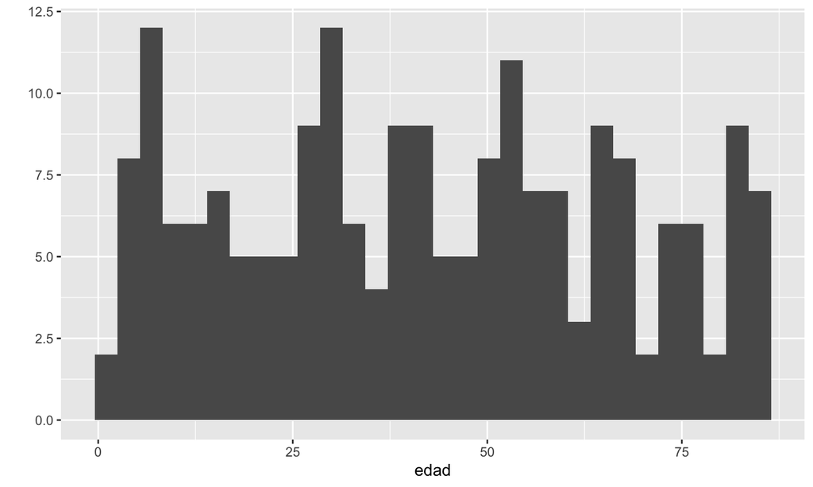

```r
qplot(edad,data= datos)
```

## Histograma dividido

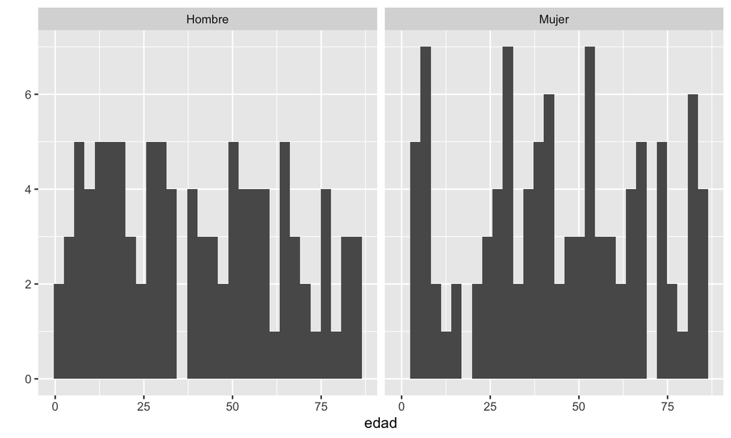

```r
qplot(edad,data= datos,facets = ~ sexo)
```

**Ejercicio:** Crea un histograma de la variable peso según sexo.

## Histograma (numero de intervalos)

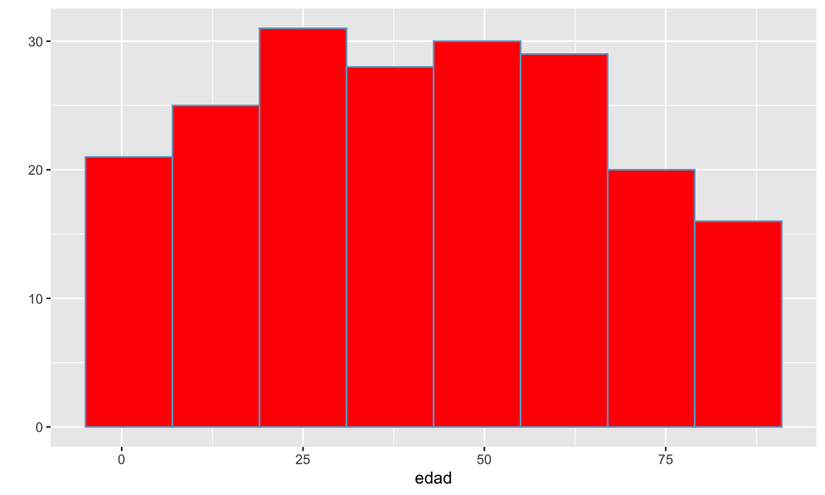

```r
qplot(edad,data= datos,bins=8,color=I("skyblue3"),fill= I("red"))
```

## Histograma (relleno)

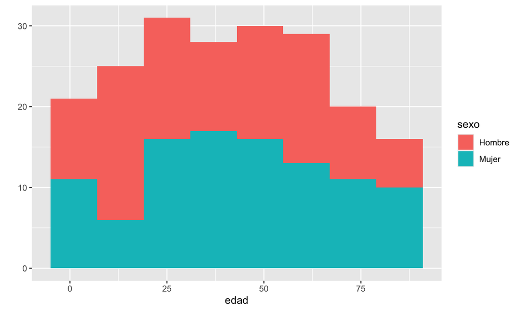

```r
qplot(edad,data=datos,bins=8,fill=sexo)
```

**Ejercicio:** Crea un histograma de la variable edad según estatus de diabetes. Muestra un total de 10 columnas.

## Boxplot

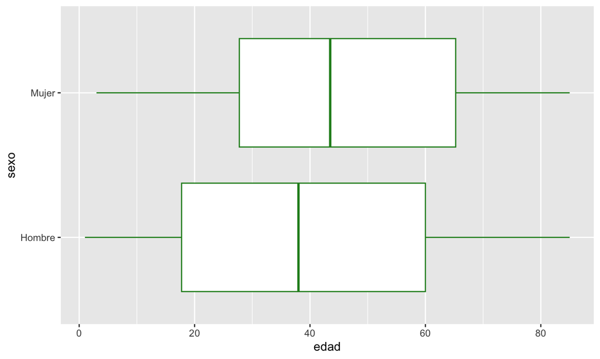

```r
 qplot(edad,sexo,data=datos,geom="boxplot",xlab="edad",
 color=I("forestgreen"))
```

**Ejercicio:** Crea un boxplot de la variable peso según el hábito tabáquico.

## Distribución de una variable (categórica)

## Diagrama de barras

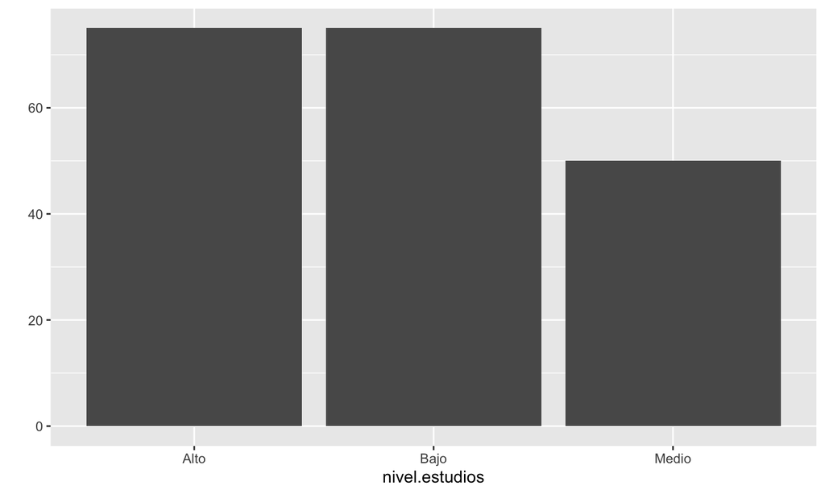

```r
 qplot(nivel.estudios,data=datos)
```

## Diagrama de barras (relleno)

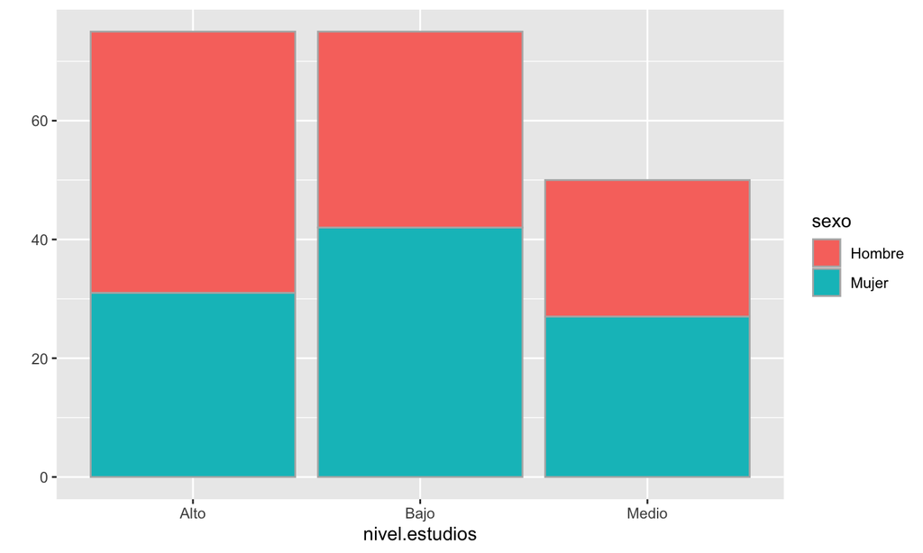

```r
 qplot(nivel.estudios,data=datos,fill=sexo,color=I("grey70"))
```

## Piechart

No se puede hacer un piechart con qplot porque está en desuso

```r
tabla<-table(datos$nivel.estudios)
porcentaje <- prop.table(tabla) * 100

df_porcentaje <- data.frame(
  categoria = names(porcentaje),
  porcentaje = as.numeric(porcentaje)
)

qplot(x = "", y = porcentaje, fill = categoria, data = df_porcentaje,
      geom = "bar", stat = "identity", width = 1)
```

```
## Error:
## ! The `stat` argument of `qplot()` was deprecated in ggplot2 2.0.0 and
##   is now defunct.
```

## Relación/Correlación de dos variables

## Scatter plot

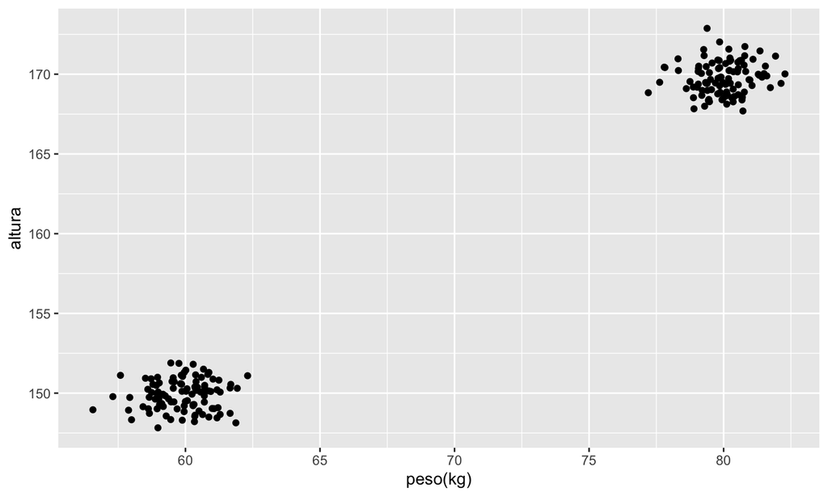

```r
 qplot(peso,altura,data=datos,xlab="peso(kg)")
```

## Scatter plot ajuste

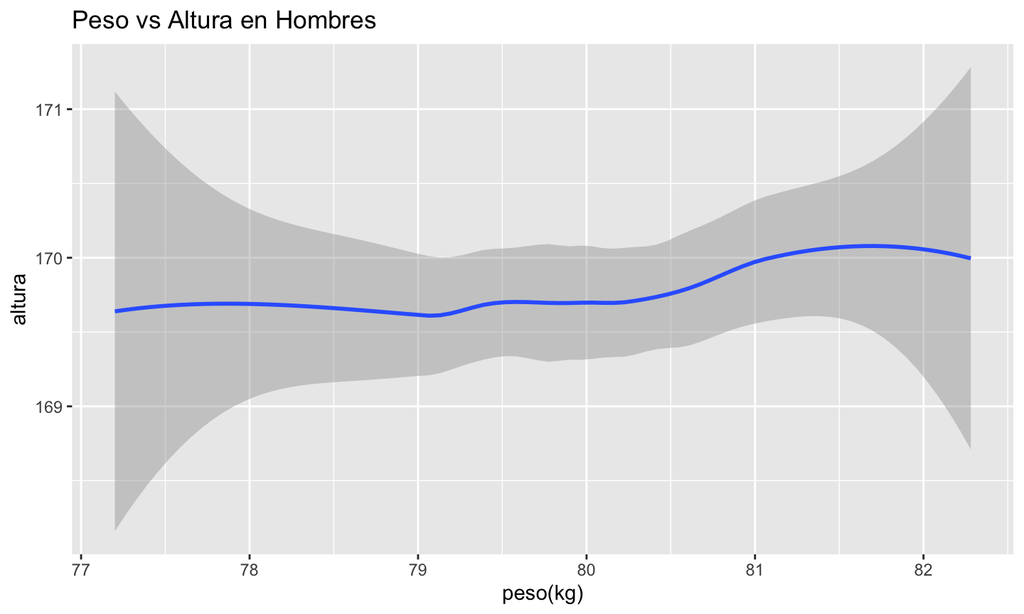

```r
qplot(peso,altura,data=subset(datos,datos$sexo=="Hombre"),xlab="peso(kg)",geom="smooth",
      main="Peso vs Altura en Hombres")
```

**Ejercicio:** Estudia la relación entre el peso y la altura de los diabéticos con una curva de suavizado.

## Scatter plot ajuste estratificado

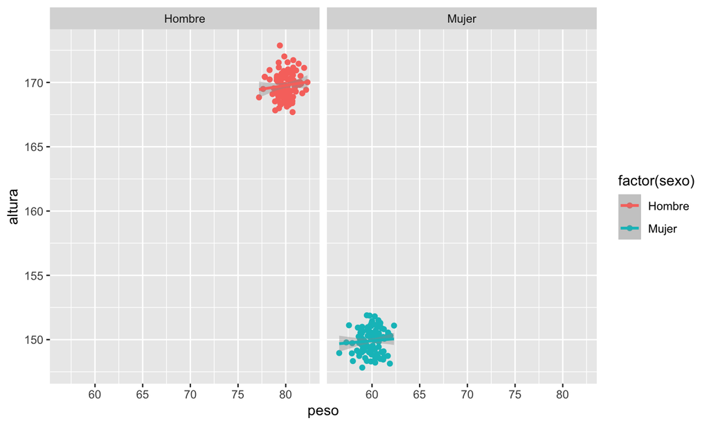

```r
 qplot(peso, altura, data = datos, facets = .~factor(sexo), color = factor(sexo))+ geom_smooth(method = "lm")
```

```r
# metodo linear modeling, regresion lineal
```

## Scatter plot line + punto

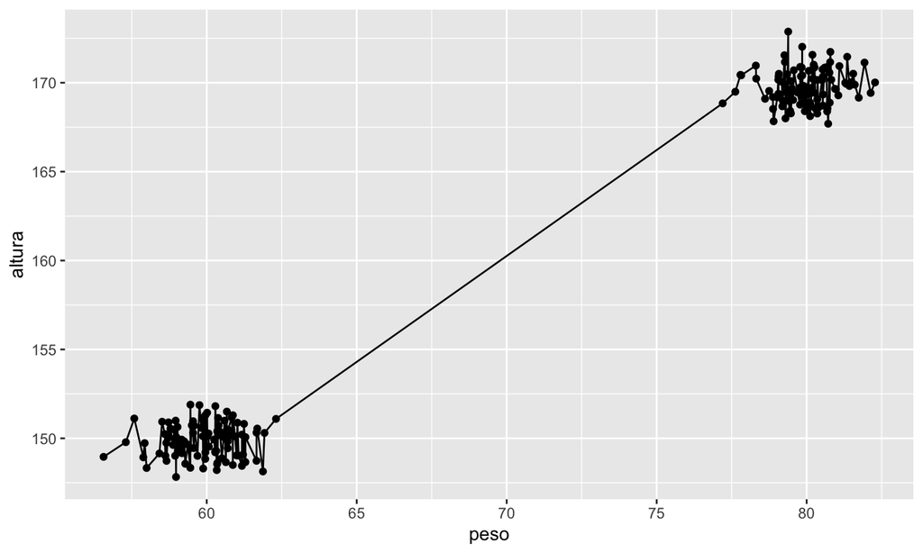

```r
 qplot(peso, altura, data=datos, geom=c("point", "line"))
```

## Scatter plot line + identificación

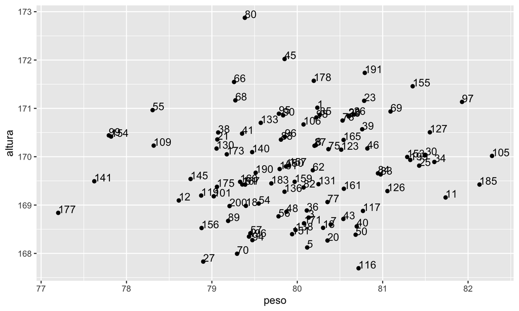

```r
qplot(peso, altura, data = subset(datos,datos$sexo=="Hombre"), label = ID,
      geom=c("point", "text"),
      hjust=0, vjust=0)
```

## Jittering

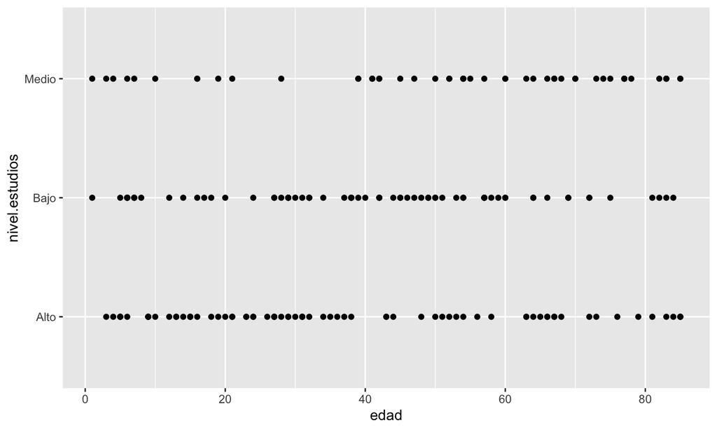

```r
qplot(edad,nivel.estudios,data=datos)
```

## Jittering

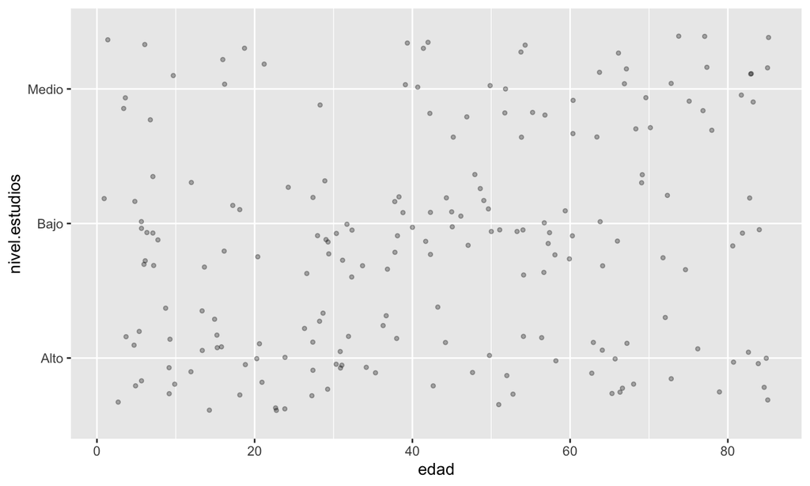

```r
 qplot(edad,nivel.estudios,data=datos,alpha=I(0.3),size=I(1),geom="jitter")
```

**Ejercicio:** Estudia la relación entre el peso y la diabetes aplicando un diagrama de dispersión evitando el solapamiento.

## Ejercicios

**1. Representa la distribución de la variable edad mediante un histograma con 8 intervalos (bins).**

- Cambia el color del borde de las barras a azul.
- Usa un relleno de color gris claro para el interior de las barras.

**2. Construye un gráfico de barras de la variable diabetes.**

- Representa el número de personas con diabetes y sin diabetes.
- Asigna un color diferente a cada categoría de diabetes.

**3. Crea un diagrama de cajas para analizar cómo varía el peso según el estado civil de las personas.**

- El color del contorno de las cajas debe ser negro.
- Rellena cada caja con un color distinto dependiendo del estado civil.
- Añade un título descriptivo al gráfico.

## Ejercicios

**4. Representa en un gráfico de dispersión (scatter plot) la relación entre la altura y el peso de los individuos.**

- Dibuja los puntos en color rojo con un tamaño mayor que el predeterminado.
- Añade una curva suavizada.

**5. Queremos visualizar la relación entre la edad y el nivel de estudio, teniendo en cuenta también la presencia de cáncer de mama.**

- Utiliza un gráfico con jittering para evitar la superposición de los puntos.
- Ajusta el jitter para que los puntos se dispersen un poco en el eje X, pero no se desplacen en el eje Y.
- Colorea los puntos según si la persona tiene cáncer de mama.